# Modelo Tobit — Práctico A: Lluvia en Sydney

MCI002 · Universidad de La Frontera

Diego Müller

2026-06-18

> **Caso:** lluvia diaria en Sydney (mm). En los días secos vale **0**, así que la variable está **censurada por la izquierda en 0**. Es el caso “real y difícil”: el ajuste es modesto y los supuestos del Tobit **no** se cumplen.

## 0. Paquetes

```r
# Solo la primera vez:
# install.packages(c("censReg", "crch", "lmtest", "ggplot2"))
library(censReg)   # Tobit por máxima verosimilitud
library(crch)      # Tobit heterocedástico (para el test de homocedasticidad)
library(lmtest)    # test de razón de verosimilitud (lrtest)
library(ggplot2)   # gráficos
```

## 1. Datos

```r
url   <- "https://raw.githubusercontent.com/1mulerd/workshop4-tobit-mci002/main/data/lluvia_tobit.csv"
datos <- read.csv(url)

# Fórmula del modelo (se usa igual en OLS y en Tobit)
f <- lluvia_mm ~ temp_max + viento_max + humedad_pm + presion_pm + nubosidad_pm

c(observaciones = nrow(datos), dias_secos = sum(datos$lluvia_mm == 0))
```

```
## observaciones    dias_secos
##          2948          1895
```

El 64 % de los días registra `lluvia_mm = 0`: una gran masa de datos en el límite de censura, que es justamente lo que motiva usar Tobit.

## 2. La censura se ve en el histograma

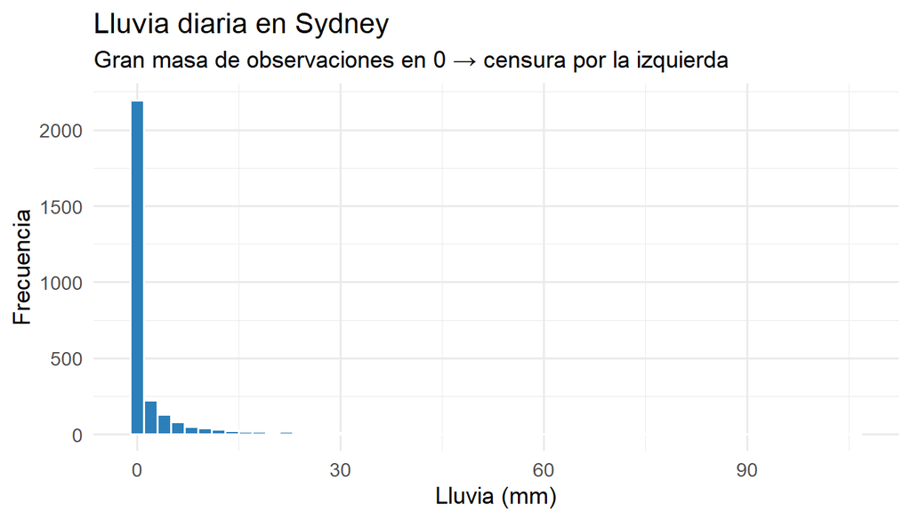

```r
ggplot(datos, aes(lluvia_mm)) +
  geom_histogram(binwidth = 2, fill = "#2c7fb8", color = "white") +
  labs(title = "Lluvia diaria en Sydney",
       subtitle = "Gran masa de observaciones en 0 → censura por la izquierda",
       x = "Lluvia (mm)", y = "Frecuencia") +
  theme_minimal(base_size = 13)
```

## 3. OLS ingenuo vs Tobit

OLS ignora la censura y termina prediciendo lluvias **negativas** (imposibles). Tobit modela la censura por máxima verosimilitud y lo corrige.

```r
ols   <- lm(f, data = datos)                 # ignora la censura
tobit <- censReg(f, left = 0, data = datos)  # Tobit: censura izquierda en 0

sum(fitted(ols) < 0)            # predicciones imposibles de OLS
```

```
## [1] 504
```

```r
round(coef(summary(tobit)), 3) # coeficientes del Tobit
```

```
##              Estimate Std. error t value Pr(> t)
## (Intercept)   202.211     64.119   3.154   0.002
## temp_max       -0.723      0.087  -8.268   0.000
## viento_max      0.188      0.028   6.753   0.000
## humedad_pm      0.361      0.026  13.953   0.000
## presion_pm     -0.223      0.062  -3.590   0.000
## nubosidad_pm    0.816      0.175   4.657   0.000
## logSigma        2.759      0.023 119.384   0.000
```

Todos los coeficientes son significativos y con **signo físico correcto**: humedad (+), nubosidad (+), viento (+), presión (−), temperatura (−).

## 4. Efectos marginales

El coeficiente Tobit es el efecto sobre la variable **latente** $y^*$. El efecto sobre la lluvia **observada** es menor (se “encoge” por la probabilidad de estar censurado), y es lo que de verdad reportamos.

```r
round(margEff(tobit), 4)   # efecto sobre E[lluvia observada]
```

```
##     temp_max   viento_max   humedad_pm   presion_pm nubosidad_pm
##      -0.2049       0.0532       0.1023      -0.0631       0.2312
```

## 5. Métricas de ajuste

El $R^2$ clásico no sirve en Tobit. Reportamos tres pseudo-$R^2$ y comparamos con OLS.

```r
b     <- coef(tobit)
sigma <- exp(b["logSigma"])     # escala del error latente
beta  <- head(b, -1)            # coeficientes (todo menos logSigma)
xb    <- as.numeric(model.matrix(f, datos) %*% beta)   # índice latente x'β
nulo  <- censReg(lluvia_mm ~ 1, left = 0, data = datos) # modelo nulo (para McFadden)

# E[lluvia observada] según Tobit (siempre ≥ 0)
pred_tob <- pnorm(xb / sigma) * xb + sigma * dnorm(xb / sigma)
```

```r
round(c(
  McKelvey_Zavoina = var(xb) / (var(xb) + sigma^2),          # principal (latente)
  McFadden         = as.numeric(1 - logLik(tobit) / logLik(nulo)),
  cor2_observada   = cor(datos$lluvia_mm, pred_tob)^2
), 3)
```

```
## McKelvey_Zavoina.logSigma                  McFadden            cor2_observada
##                     0.269                     0.059                     0.158
```

```r
rmse <- function(y, p) sqrt(mean((y - p)^2))
tabla <- data.frame(
  Modelo         = c("OLS", "Tobit"),
  AIC            = c(AIC(ols), AIC(tobit)),
  RMSE           = c(rmse(datos$lluvia_mm, fitted(ols)), rmse(datos$lluvia_mm, pred_tob)),
  Pred_imposibles = c(sum(fitted(ols) < 0), sum(pred_tob < 0))
)
knitr::kable(tabla, digits = 2, caption = "OLS vs Tobit")
```

OLS vs Tobit

| Modelo | AIC | RMSE | Pred_imposibles |
| --- | --- | --- | --- |
| OLS | 21031.86 | 8.55 | 504 |
| Tobit | 10375.11 | 8.43 | 0 |

## 6. Diagnóstico de supuestos

En Tobit, si fallan la **normalidad** o la **homocedasticidad** del error, el MLE es **sesgado e inconsistente** (no solo ineficiente como en OLS). Por eso se testean.

### 6.1 Residuos generalizados (Chesher–Irish)

```r
# y > 0  → residuo estándar ;  y = 0 → error truncado esperado
res <- ifelse(datos$lluvia_mm == 0,
              -dnorm(xb / sigma) / pnorm(-xb / sigma),
              (datos$lluvia_mm - xb) / sigma)
```

### 6.2 Normalidad: Jarque-Bera

```r
S  <- mean((res - mean(res))^3) / sd(res)^3   # asimetría
K  <- mean((res - mean(res))^4) / sd(res)^4   # curtosis
JB <- length(res) / 6 * (S^2 + (K - 3)^2 / 4) # ~ chi² (2) bajo normalidad

round(c(asimetria = S, curtosis = K, Jarque_Bera = JB,
        p_valor = pchisq(JB, df = 2, lower.tail = FALSE)), 3)
```

```
##   asimetria    curtosis Jarque_Bera     p_valor
##       2.198      11.601   11459.338       0.000
```

`p ≈ 0` → la normalidad se **rechaza**. (Evidencia extra: un error t-Student, de colas pesadas, ajusta mucho mejor según AIC.)

```r
c(AIC_normal = AIC(crch(f, data = datos, left = 0, dist = "gaussian")),
  AIC_tStudent = AIC(crch(f, data = datos, left = 0, dist = "student")))
```

```
##   AIC_normal AIC_tStudent
##     10375.11      9707.75
```

### 6.3 Homocedasticidad: test LR (Tobit homo vs heterocedástico)

```r
homo <- crch(f, data = datos, left = 0, dist = "gaussian")
het  <- crch(lluvia_mm ~ temp_max + viento_max + humedad_pm + presion_pm + nubosidad_pm |
                         temp_max + viento_max + humedad_pm + presion_pm + nubosidad_pm,
             data = datos, left = 0, dist = "gaussian")
lrtest(homo, het)   # H0: errores homocedásticos
```

```
## Likelihood ratio test
##
## Model 1: lluvia_mm ~ temp_max + viento_max + humedad_pm + presion_pm +
##     nubosidad_pm
## Model 2: lluvia_mm ~ temp_max + viento_max + humedad_pm + presion_pm +
##     nubosidad_pm | temp_max + viento_max + humedad_pm + presion_pm +
##     nubosidad_pm
##   #Df  LogLik Df  Chisq Pr(>Chisq)
## 1   7 -5180.6
## 2  12 -5033.3  5 294.55  < 2.2e-16 ***
## ---
## Signif. codes:  0 '***' 0.001 '**' 0.01 '*' 0.05 '.' 0.1 ' ' 1
```

`p < 0.001` → la homocedasticidad también se **rechaza**.

### 6.4 QQ-plot de residuos generalizados

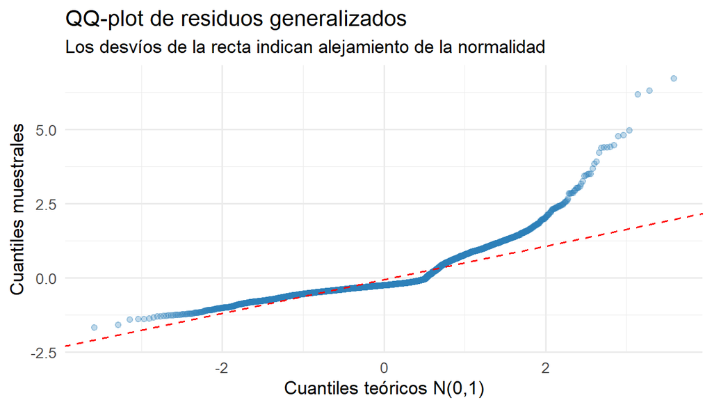

```r
ggplot(data.frame(r = res), aes(sample = r)) +
  stat_qq(alpha = 0.3, color = "#2c7fb8") +
  stat_qq_line(color = "red", linetype = 2) +
  labs(title = "QQ-plot de residuos generalizados",
       subtitle = "Los desvíos de la recta indican alejamiento de la normalidad",
       x = "Cuantiles teóricos N(0,1)", y = "Cuantiles muestrales") +
  theme_minimal(base_size = 13)
```

## 7. Conclusión del práctico A

Tobit elimina las predicciones imposibles de OLS y entrega coeficientes con sentido físico, **pero** la normalidad y la homocedasticidad se rechazan: el ajuste es modesto (McKelvey–Zavoina ≈ 0.27) y el Tobit básico es inconsistente. Aquí correspondería una versión **heterocedástica o robusta**.